# PulmonDB - COVID19.

PCA data exploration

Monica Padilla

## **PCA of 3 parallel analysis**

`celllines`: Infected vs mock cell lines (Blanco 2020), `lung-covid`: Lung COVID vs Healthy (Blanco 2020, Desai 2020, Delorey 2021) and `organs-desgtex`: COVID tissues vs healthy (Desai 2020, GTEx v8)

Original sources: Delorey et al, 2021 [1], Desai et al. 2020 [2], Blanco, GTEx Data preprocessing and matrixes for each experiment generation is described in another report.

Explore overall transcriptomic profile of count matrixes that will be used for further analysis.

### **Prepare terminal**

```bash
ssh -Y mpadilla@dna.liigh.unam.mx
screen -S search
qlogin
cd /mnt/Citosina/amedina/mpadilla/COVID19/pca
module unload r/3.2.1
module load r/4.0.2
umask 2

mkdir plots_3analysis-bc
```

### **Cell lines**

#### **All celllines experiments**

##### **Load and clean data**

```r
library(tidyverse)
library(ggrepel)

## axes titles PC % explained var
pc.axis <- function(PCnum){
  paste0("PC",PCnum," (",
         summary(pca)$importance[2,][PCnum]*100,
         "% explained var.)")
}

# metadata
meta <- as.data.frame(read.csv("/mnt/Citosina/amedina/mpadilla/COVID19/Data/multi-datasets/metadata/meta_sample-source.tsv", sep ="\t", header = F))
colnames(meta) <- c("sample", "source")

# counts matrix - batch corrected
celllines <- as.data.frame(read.csv(file = "/mnt/Citosina/amedina/mpadilla/COVID19/Data/blanco2020/counts3/blanco2020_adj-celllines_wINFBNHBE-counts-fltrtrxs.csv", sep = ","))
dim(celllines) # 74 20299

sub.celllines <- str_detect(meta$source, "Mock") | str_detect(meta$source, "infected") | str_detect(meta$source, "IFNB_treated_NHBE")
# subset for celllines samples
meta.sub <- meta[sub.celllines,]

## filter genes with zero counts and replace 0s for NAs
celllines[is.na(celllines)] <- 0
celllines <- celllines[,which(apply(celllines, 2, var) != 0)] #  74 19035
```

##### **PCA**

Label vectors:

```r
# order meta
order <- match(rownames(celllines),meta.sub$sample)
meta.sub <- meta.sub[order,]

# Create vector of experiment labels
exprmts <- rev(unique(meta.sub$source))
exprmts.short <- rev(c("hIFNB NHBE", "SC2-inf-NHBE", "SC2-inf-Calu3", "SC2-inf-A549 + ACE2 + pt",
                       "SC2-inf-A549 + ACE2", "SC2-inf-A549", "RSV-inf-A549", "Mock NHBE",
                       "Mock Calu3", "Mock A549 + ACE2", "Mock A549", "IAVdNS1-inf-NHBE",
                       "IAV-inf-NHBE", "IAV-inf-A549", "HPIV3-inf-A549"))
experiments <- meta.sub$source
for (i in 1:length(exprmts)) {
  experiments <- str_replace(experiments, exprmts[i], exprmts.short[i])
  i = i + 1
}
```

PCA computation and visualization

```r
pca <- prcomp(celllines, scale = T)

## add labels to pca obj
pca$x <- add_column(as.data.frame(pca$x), experiments)

## ggplot2 col-SC2inf  shape -experiments
png(file = "./plots_3analysis-bc/celllines/pca_blanco2020_all-celllines-exp_PC56.png", width = 1000, height = 800)
ggplot(pca$x, aes(x=PC5, y=PC6, group=experiments)) +
  geom_point(size=4, aes(shape=experiments, color=experiments)) +
  stat_ellipse(aes(color=experiments), show.legend = F) +
  #geom_mark_ellipse(aes(label=experiments,color=experiments), show.legend = F) +
  scale_shape_manual(values=c(0:14), name="Experiment") +
  scale_colour_discrete(name="Experiment") +
  labs(x = pc.axis(5), y = pc.axis(6)) +
  theme(legend.position = "top", legend.title = element_text(face = "bold"),
        axis.title.x=element_text(face = "bold"), axis.title.y=element_text(face = "bold")) +
  geom_text( aes(label=experiments,color=experiments),
             nudge_x = 8, nudge_y = 8, show.legend = F, check_overlap = T)
dev.off()
```

- `Mock Calu-3` : Mock treated Calu-3 cell lines samples
- `Mock NHBE` : Mock treated NHBE cell lines samples
- `Mock A549` : Mock treated A459 cell lines samples
- `Mock A549+ACE2` : Mock treated A459 cell lines with vector expression of ACE2 samples
- `SC2-inf-A549` : SARS-CoV-2 infected A459 cell lines samples
- `SC2-inf-A549+ACE2` : SARS-CoV-2 infected A459 cell lines with vector expression of ACE2 samples
- `SC2-inf-A549+ACE2+pt` : SARS-CoV-2 infected A459 cell lines with vector expression of ACE2 with 1hr Ruxolitinib pre-treatment (IFN-I signaling blocked) samples
- `SC2-inf-Calu3` : SARS-CoV-2 infected Calu-3 cell lines samples
- `SC2-inf-NHBE` : SARS-CoV-2 infected NHBE cell lines samples
- `RSV-inf-A549` : RSV infected A459 cell lines samples
- `IAVdNS1-inf-NHBE` : IAVdNS1 infected NHBE cell lines samples
- `IAV-inf-NHBE` : IAV infected NHBE cell lines samples
- `IAV-inf-A549` : IAV infected A459 cell lines samples
- `HPIV3-inf-A549` : HPIV3 infected A459 cell lines samples
- `hIFNB NHBE` : NHBE cell lines samples treated with human Interferon-β (IFN-β)
- PC1&2

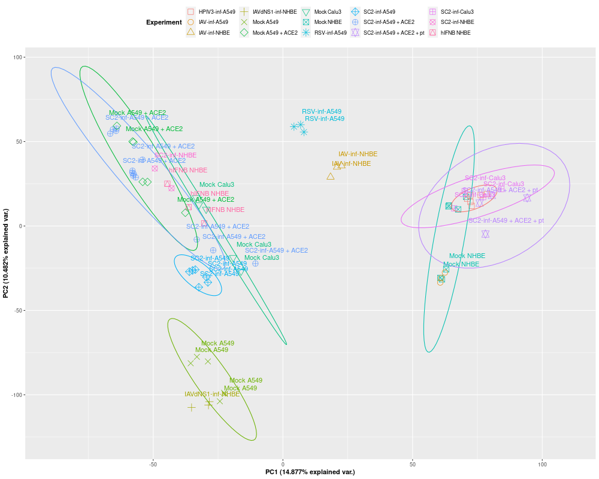

I think that what we’re seeing here is that the `PC1` is separating experiments by expression of Interferon and its associated genes or the lack of it. Because at the right is the experiment `SARS-CoV-2-infected-A549 + ACE2 expression + Ruxolitinib pretreatment` (purple stars) and `Mock NHBE` (green squares), whereas at the left is the experiment `hINFB NHBE` which should be expressing and exacerbated INF response in comparision to its control.

`SARS-CoV-2 A549 infected` samples wihtout pre-treatment are clustering togetherat the uppper left position, joined by `SARS-CoV-2 NHBE infected`, `hINFB NHBE` and close together to `ACE2 expressing samples` is the `Mock A549 + ACE2`.

- PC3&4

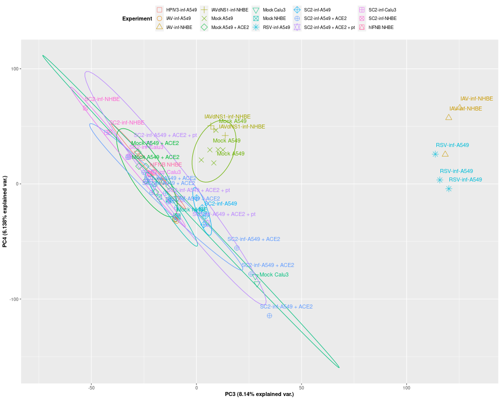

Response to `IAV` and `RSV` infection seem to be very different from the rest.

- PC5&6

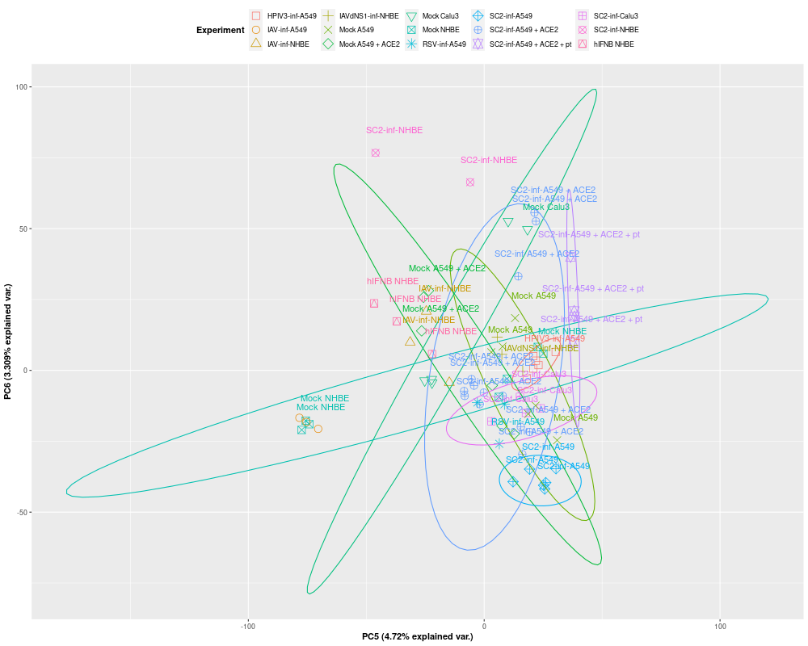

- PC7&8

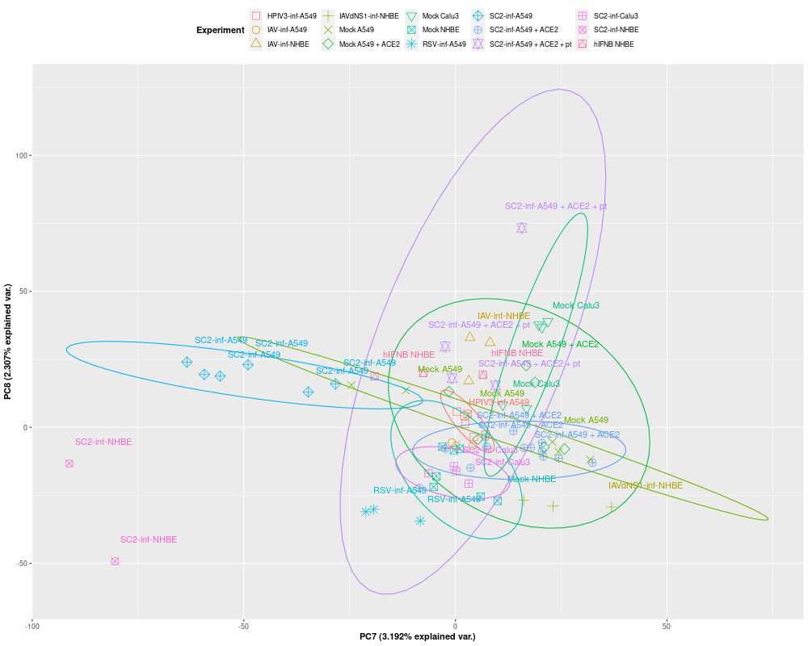

#### **All celllines experiments except hIFNB treated NHBE**

##### **Load and clean data**

```r
# counts matrix - batch corrected
celllines <- as.data.frame(read.csv(file = "/mnt/Citosina/amedina/mpadilla/COVID19/Data/blanco2020/counts3/blanco2020_adj-celllines_noINFBNHBE-counts-fltrtrxs.csv", sep = ","))
dim(celllines) # 68 20299

# subset metadata
sub.celllines <- str_detect(meta$source, "Mock") | str_detect(meta$source, "infected")
# subset for celllines samples
meta.sub <- meta[sub.celllines,]

## filter genes with zero counts and replace 0s for NAs
celllines[is.na(celllines)] <- 0
celllines <- celllines[,which(apply(celllines, 2, var) != 0)] #  68 18982
```

##### **PCA**

Label vectors:

```r
# order meta
order <- match(rownames(celllines),meta.sub$sample)
meta.sub <- meta.sub[order,]

# Create vector of experiment labels
exprmts <- rev(unique(meta.sub$source))
exprmts.short <- rev(c("SC2-inf-NHBE", "SC2-inf-Calu3", "SC2-inf-A549 + ACE2 + pt",
                       "SC2-inf-A549 + ACE2", "SC2-inf-A549", "RSV-inf-A549", "Mock NHBE",
                       "Mock Calu3", "Mock A549 + ACE2", "Mock A549", "IAVdNS1-inf-NHBE",
                       "IAV-inf-NHBE", "IAV-inf-A549", "HPIV3-inf-A549"))
experiments <- meta.sub$source
for (i in 1:length(exprmts)) {
  experiments <- str_replace(experiments, exprmts[i], exprmts.short[i])
  i = i + 1
}
```

PCA computation and visualization

```r
pca <- prcomp(celllines, scale = T)

## add labels to pca obj
pca$x <- add_column(as.data.frame(pca$x), experiments)

## ggplot2 col-SC2inf  shape -experiments
png(file = "./plots_3analysis-bc/celllines/pca_blanco2020_celllines-exp-noINFBNHBE_PC12.png", width = 1000, height = 800)
ggplot(pca$x, aes(x=PC1, y=PC2, group=experiments)) +
  geom_point(size=4, aes(shape=experiments, color=experiments)) +
  stat_ellipse(aes(color=experiments), show.legend = F) +
  scale_shape_manual(values=c(0:13), name="Experiment") +
  scale_colour_discrete(name="Experiment") +
  labs(x = pc.axis(1), y = pc.axis(2)) +
  theme(legend.position = "top", legend.title = element_text(face = "bold"),
        axis.title.x=element_text(face = "bold"), axis.title.y=element_text(face = "bold")) +
  geom_text( aes(label=experiments, color=experiments), nudge_x = 8, nudge_y = 8, show.legend = F)
dev.off()
```

### **Tissues COVID vs Healthy**

This experiment was causing a lot of bias in the exploratory analysis where all count matrixes were merged together. In general, it was expected since there where a lot of different sources. To minimize that technical bias, the analysis was split as shown in this report. For this experiment of **Tissues COVID vs Healthy** or `organs-desgtex`, there is still expected to have a technical bias since we could only get a good number of cases and control samples each from different sources, that is, Desai COVID-19 samples and GTEx healthy samples. Batch correction was performed jointly or separately taking into account dataset and experiment technical variation sources.

#### **Desai and GTEx: Lung, Liver, Heart, Kidney, Bowel - Corrected separately**

##### **Load, join and clean data**

```r
# counts matrix - batch corrected
gtex <- as.data.frame(read.csv("/mnt/Citosina/amedina/mpadilla/COVID19/Data/gtex_v8-fltr/GTEx_v8-RNASEQ-subTissues-adj-counts-fltrensg.csv", sep = ","))
dim(gtex) #   50 13697

desai <- as.data.frame(read.csv("/mnt/Citosina/amedina/mpadilla/COVID19/Data/desai2020/kallisto_gen/desai2020-counts-adj-selCovidOrgans_fltrtrxs.csv", sep = ","))
dim(desai) #  72 20299

# subset metadata
meta.sub <- as.data.frame(read.csv("/mnt/Citosina/amedina/mpadilla/COVID19/Data/multi-datasets/metadata/desai2020_gtexv8-subTissues-sample_source.csv", sep = ","))

## Join datasets
desai.g <- rownames_to_column(as.data.frame(t(desai)), var = "gene")
gtex.g <- rownames_to_column(as.data.frame(t(gtex)), var = "gene")
multiorg <- full_join(desai.g, gtex.g, by = "gene")
multiorg <- t(column_to_rownames(multiorg, var = "gene"))
dim(multiorg) #  122 20381

## filter genes with zero counts and replace 0s for NAs
multiorg[is.na(multiorg)] <- 0
multiorg <- multiorg[,which(apply(multiorg, 2, var) != 0)] #   122 19613
```

##### **PCA**

Label vectors:

```r
# order meta
order <- match(rownames(multiorg),meta.sub$sample)
meta.sub <- meta.sub[order,]

# Create vector of experiment labels
experiments <- meta.sub$source
dataset <- meta.sub$dataset
```

PCA computation and visualization

```r
pca <- prcomp(multiorg, scale = T)

## add labels to pca obj
pca$x <- add_column(as.data.frame(pca$x), experiments)
# pca$x <- add_column(as.data.frame(pca$x), dataset)

## ggplot2 col-SC2inf  shape -experiments
png(file = "./plots_3analysis-bc/multiorgans/pca_desai2020-gtexv8_subTissues_PC78-labhealthy.png",
    width = 800, height = 800)
ggplot(pca$x, aes(x=PC7, y=PC8, group=experiments)) +
  geom_point(size=4, aes(shape=experiments, color=experiments)) +
  stat_ellipse(aes(color=experiments), show.legend = F) +
  scale_shape_manual(values=c(0:9), name="Tissue") +
  scale_colour_discrete(name="Tissue") +
  labs(x = pc.axis(7), y = pc.axis(8)) + #xlim(57.017922,57.017925) + ylim(3.9374615,3.937462) +
  theme(legend.position = "top", legend.title = element_text(face = "bold"),
        axis.title.x=element_text(face = "bold"), axis.title.y=element_text(face = "bold")) +
  geom_text(aes(label=experiments,color=experiments),
            nudge_x = 8, nudge_y = 8, show.legend = F, check_overlap = T) +
  geom_label_repel(data = pca$x %>% select(PC7,PC8,experiments) %>%
                     slice(c(73,75,76,79,84)), aes(label=experiments,color=experiments),
             nudge_x = 55, nudge_y = 55, show.legend = F)
dev.off()
```

- PC1&2

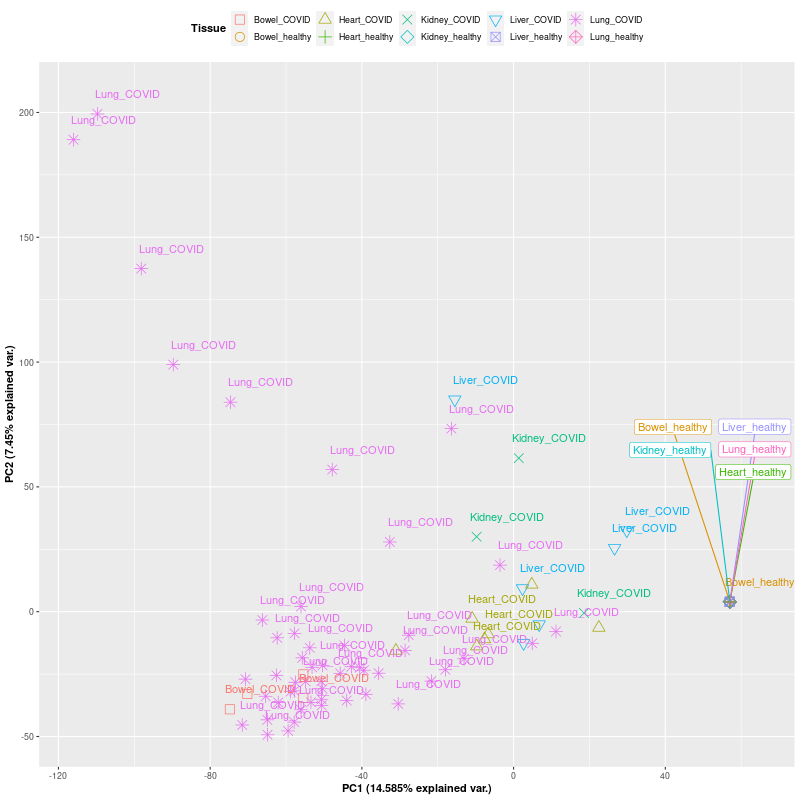

PC1 is separating samples by source dataset.

- PC3&4

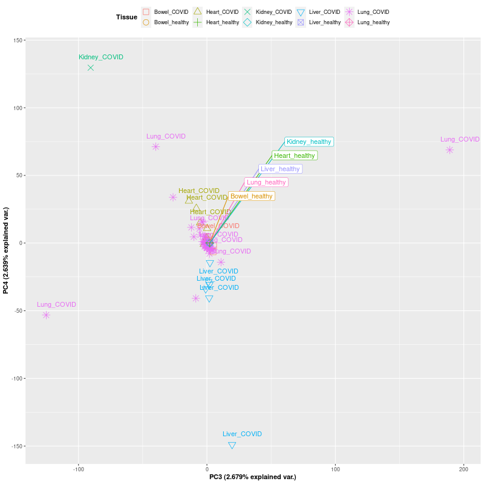

We can see now that samples from different datasets merge together, however GTEx healthy samples are still clustered together at one point.

- PC5&6

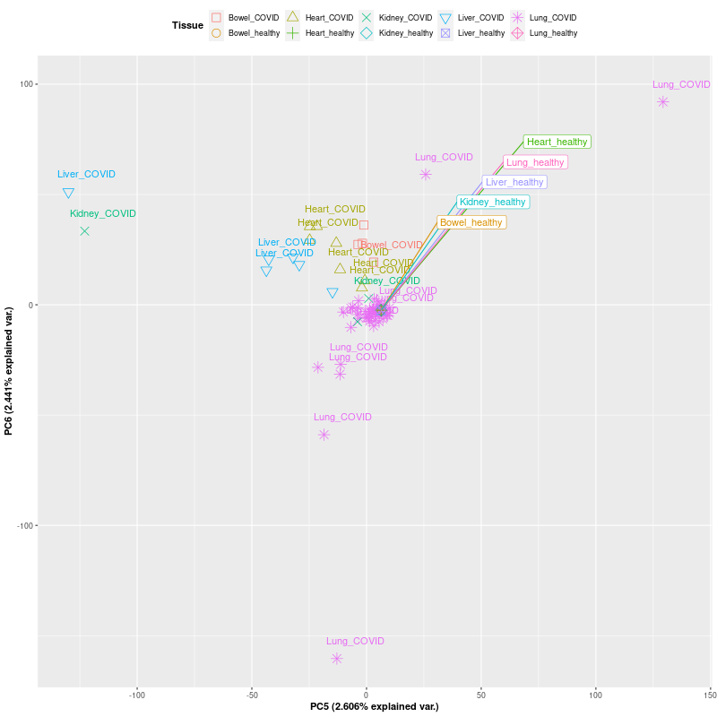

- PC7&8

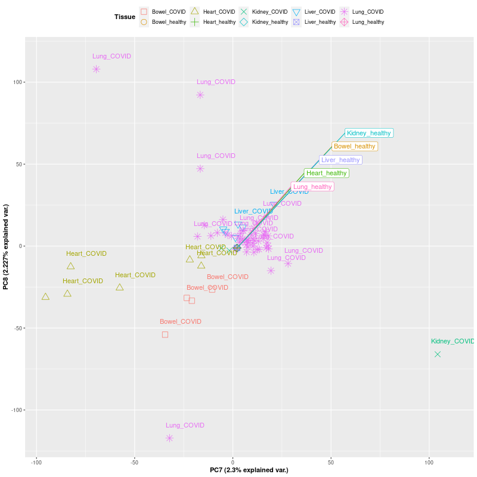

#### **Desai and GTEx: Lung, Liver, Heart, Kidney, Bowel - Corrected together**

##### **Load, join and clean data**

```r
# counts matrix - batch corrected
multiorg <- as.data.frame(read.csv("/mnt/Citosina/amedina/mpadilla/COVID19/Data/multi-datasets/counts/desai2020_gtexv8-subTissues-adj_countsfltrtrxs.csv", sep = ","))
dim(multiorgans) #   122 20299

# subset metadata
meta.sub <- as.data.frame(read.csv("/mnt/Citosina/amedina/mpadilla/COVID19/Data/multi-datasets/metadata/desai2020_gtexv8-subTissues-sample_source.csv", sep = ","))

## filter genes with zero counts and replace 0s for NAs
multiorg[is.na(multiorg)] <- 0
multiorg <- multiorg[,which(apply(multiorg, 2, var) != 0)] #   122 20299
```

##### **PCA**

Label vectors:

```r
# order meta
order <- match(rownames(multiorg),meta.sub$sample)
meta.sub <- meta.sub[order,]

# Create vector of experiment labels
experiments <- meta.sub$source
dataset <- meta.sub$dataset
```

PCA computation and visualization

```r
pca <- prcomp(multiorg, scale = T)

## add labels to pca obj
pca$x <- add_column(as.data.frame(pca$x), experiments)
pca$x <- add_column(as.data.frame(pca$x), dataset)

## ggplot2 col-SC2inf  shape -experiments
png(file = "./plots_3analysis-bc/multiorgans/pca_desai2020-gtexv8_subTissues_mer-adj_PC78-labhealthy.png",
    width = 800, height = 800)
ggplot(pca$x, aes(x=PC7, y=PC8, group=experiments)) +
  geom_point(size=4, aes(shape=experiments, color=experiments)) +
  stat_ellipse(aes(color=experiments), show.legend = F) +
  scale_shape_manual(values=c(0:9), name="Tissue") +
  scale_colour_discrete(name="Tissue") +
  labs(x = pc.axis(7), y = pc.axis(8)) + #xlim(57.017922,57.017925) + ylim(3.9374615,3.937462) +
  theme(legend.position = "top", legend.title = element_text(face = "bold"),
        axis.title.x=element_text(face = "bold"), axis.title.y=element_text(face = "bold")) +
  geom_text(aes(label=experiments,color=experiments),
            nudge_x = 8, nudge_y = 8, show.legend = F, check_overlap = T) +
  geom_label_repel(data = pca$x %>% dplyr::select(PC7,PC8,experiments) %>%
                     slice(c(73,75,76,79,84)), aes(label=experiments,color=experiments),
             nudge_x = 55, nudge_y = 55, show.legend = F)
dev.off()
```

- PC1&2

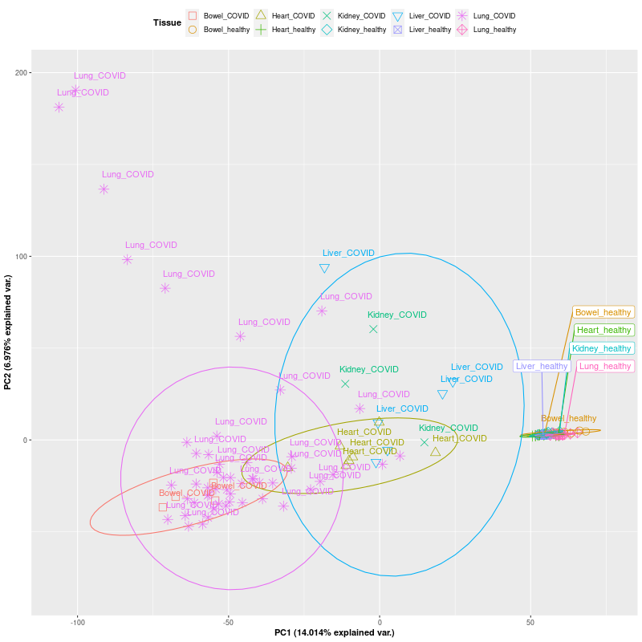

Performing batch correction with the datasets joined improved and lessened the bias. As before, PC1 separates samples by source dataset, but here `Healhty GTEx` samples are not clustered together at one point, but have dispersed a little bit and there seems to be congruence according to the tissue.

For COVID-19 samples, `Heart COVID` and `Bowel COVID` samples simulated distributions are more constrained and less disperse than those of other organs. `Liver COVID` sampels locate at the middle and `Lung COVID` samples are the most disperse, these are also the most numerous.

- PC3&4

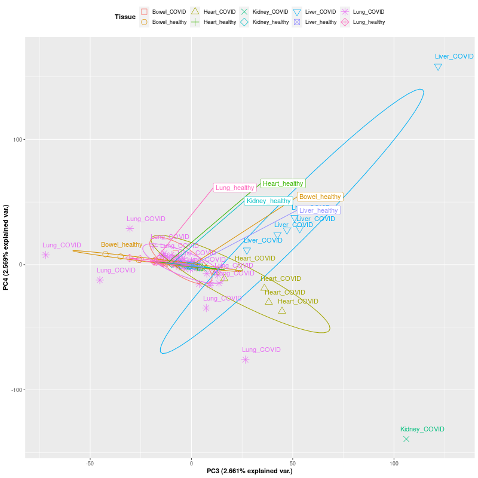

In PC3 and PC4, we see that samples from different datasets merge together and again we can see that `healthy GTEx` samples have improved in terms of dispersion.

As a conclusion, we will use this data matrix for further downstream analysis.

- PC5&6

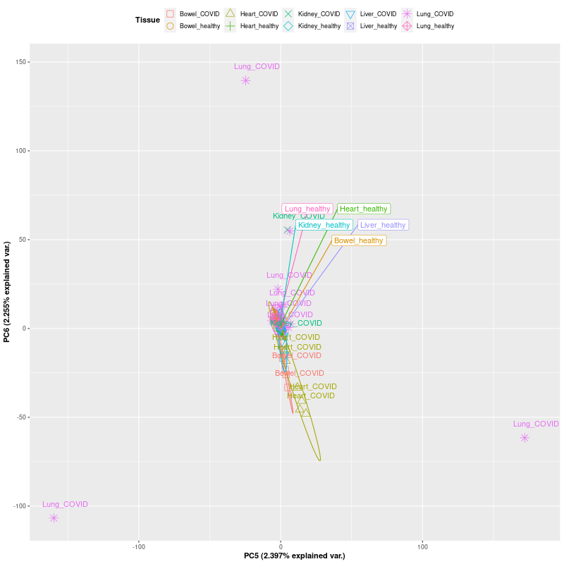

- PC7&8

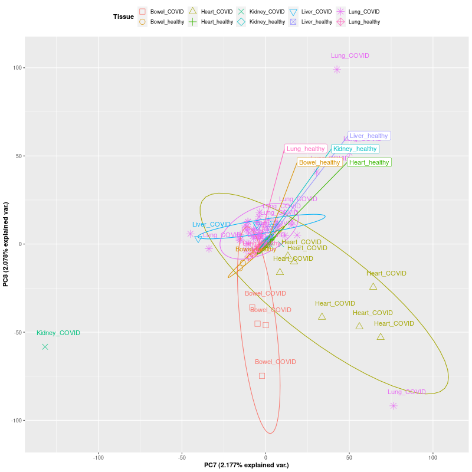

### **Lung COVID vs Healthy**

To improve the congruence between datasets and lessen the technical variance, we decided to also perform the **Lung COVID** analysis seprated from the others.

#### **Metadata Lung samples**

```r
## metadata bladesdel
meta <- as.data.frame(read.csv("/mnt/Citosina/amedina/mpadilla/COVID19/Data/multi-datasets/metadata/meta_sample-source.tsv", sep ="\t", header = F))
colnames(meta) <- c("sample", "source")

## Subset metadata for lung samples
meta.lung <- str_detect(meta$source, "[Ll]ung")
meta.sub.lung <- meta[meta.lung,]

## Change tags across dataset to match biological condition
tissue <- rev(unique(meta.sub.lung$source))
bio.cond <- meta.sub.lung$source
tissue.covid <- c("Lung_COVID","Lung_healthy","Lung_COVID","Lung_COVID","Lung_healthy")
for (i in 1:length(tissue)) {
  bio.cond <- str_replace(bio.cond, tissue[i], tissue.covid[i])
  i = i + 1
}
meta.sub.lung$source <- bio.cond

## dataset
meta.des <- str_detect(meta.sub.lung$sample, "^SAMN")
meta.del <- str_detect(meta.sub.lung$sample, "^\\d+")
dataset <- rep("Blanco_2020",length(meta.sub.lung$sample))
dataset[meta.des] <- "Desai_2020"
dataset[meta.del] <- "Delorey_2021"
meta.sub.lung[,"dataset"] <- dataset

## format delorey samples

## write out that file
write.table(x = meta.sub.lung,
            file = "/mnt/Citosina/amedina/mpadilla/COVID19/Data/multi-datasets/metadata/blanco2020-desai2020-delorey2021_allLungSamples_sample-source-dataset.csv",
            sep = ",", eol = "\n", na = "NA", row.names = F, col.names = T, quote = F)
```

#### **Blanco + Desai (batch correction separately)**

##### **Load, join and clean data**

```r
# counts matrix - batch corrected
lung <- as.data.frame(read.csv(file = "/mnt/Citosina/amedina/mpadilla/COVID19/Data/multi-datasets/counts/blanco2020_adj-desai2020_adj-Lung-counts-fltrtrxs.csv", sep = ","))
dim(lung) #    61 20299

# subset metadata
meta.lungdel <- meta.sub.lung$dataset == 3
# subset for lung samples from desai and blanco only
meta.sub <- meta.sub.lung[!meta.lungdel,]

## filter genes with zero counts and replace 0s for NAs
lung[is.na(lung)] <- 0
lung <- lung[,which(apply(lung, 2, var) != 0)] #   61 19618
```

##### **PCA**

Label vectors:

```r
# order meta
order <- match(rownames(lung),meta.sub.lung$sample)
meta.sub.lung <- meta.sub.lung[order,]

# Create vector of experiment labels
experiments <- meta.sub.lung$source
dataset <- as.factor(meta.sub.lung$dataset)
```

PCA computation and visualization

```r
library(ghibli)
pca <- prcomp(lung, scale = T)

## add labels to pca obj
pca$x <- add_column(as.data.frame(pca$x), experiments)
pca$x <- add_column(as.data.frame(pca$x), as.factor(dataset))

## ggplot2 col-SC2inf  shape -experiments
png(file = "./plots_3analysis-bc/lung/pca_blanco2020_adj-desai2020_adj-Lung-PC78.png",
    width = 800, height = 800)
ggplot(pca$x, aes(x=PC7, y=PC8, group=experiments)) +
  geom_point(size=4, aes(shape=dataset, color=experiments)) +
  stat_ellipse(aes(color=experiments), show.legend = F) +
  scale_shape_manual(values=c(15,1), name="Dataset") +
  scale_colour_manual(values=c("#f38989","#7289da"), name="Tissue") +
  labs(x = pc.axis(7), y = pc.axis(8)) +
  theme(legend.position = "top", legend.title = element_text(face = "bold"),
        axis.title.x=element_text(face = "bold"), axis.title.y=element_text(face = "bold")) +
  geom_text(aes(label=experiments,color=experiments),
            nudge_x = 8, nudge_y = 8, show.legend = F, check_overlap = T)
dev.off()
```

- PC1&2

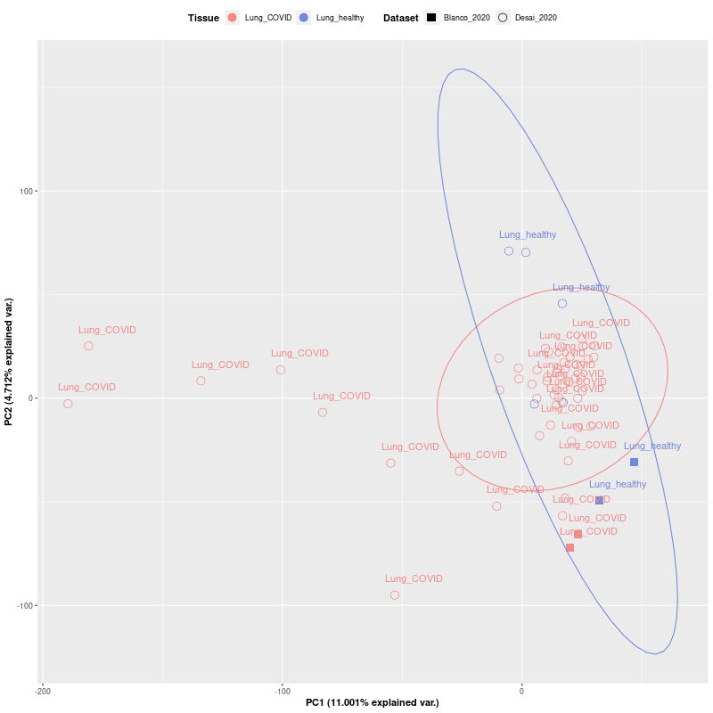

- PC3&4

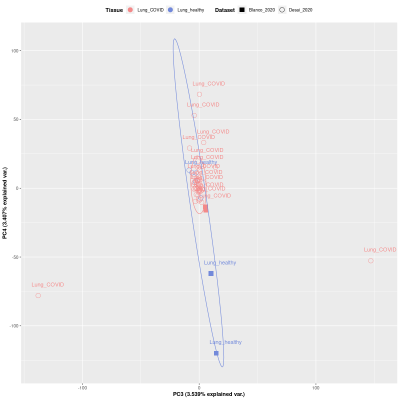

- PC5&6

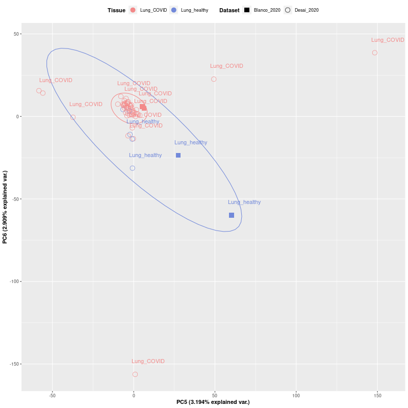

- PC7&8

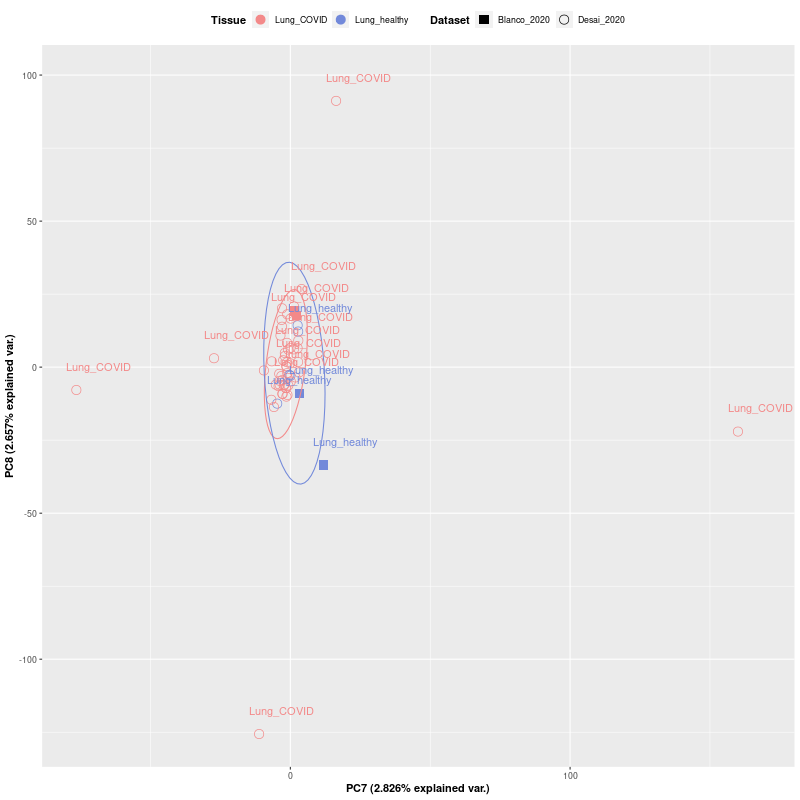

#### **Blanco + Desai (batch correction joined)**

##### **Load, join and clean data**

```r
# counts matrix - batch corrected
lung <- as.data.frame(read.csv(file = "/mnt/Citosina/amedina/mpadilla/COVID19/Data/multi-datasets/counts/blanco2020-desai2020-mer-adj-counts-Lung-fltrtrxs.csv", sep = ","))
dim(lung) #    61 20299

# subset metadata
meta.lungdel <- str_detect(meta.sub.lung$dataset, "Delorey_2021")
# subset for lung samples from desai and blanco only
meta.sub <- meta.sub.lung[!meta.lungdel,]

## filter genes with zero counts and replace 0s for NAs
lung[is.na(lung)] <- 0
lung <- lung[,which(apply(lung, 2, var) != 0)] #   61 19618
```

##### **PCA**

Label vectors:

```r
# order meta
order <- match(rownames(lung),meta.sub.lung$sample)
meta.sub.lung <- meta.sub.lung[order,]

# Create vector of experiment labels
experiments <- meta.sub.lung$source
dataset <- as.factor(meta.sub.lung$dataset)
```

PCA computation and visualization

```r
pca <- prcomp(lung, scale = T)

## add labels to pca obj
pca$x <- add_column(as.data.frame(pca$x), experiments)
pca$x <- add_column(as.data.frame(pca$x), dataset)

## ggplot2 col-SC2inf  shape -experiments
png(file = "./plots_3analysis-bc/lung/pca_blanco2020_desai2020-mer_adj-Lung-PC56.png",
    width = 800, height = 800)
ggplot(pca$x, aes(x=PC5, y=PC6, group=experiments)) +
  geom_point(size=4, aes(shape=dataset, color=experiments)) +
  stat_ellipse(aes(color=experiments), show.legend = F) +
  scale_shape_manual(values=c(15,1), name="Dataset") +
  scale_colour_manual(values=c("#f38989","#7289da"), name="Tissue") +
  labs(x = pc.axis(5), y = pc.axis(6)) +
  theme(legend.position = "top", legend.title = element_text(face = "bold"),
        axis.title.x=element_text(face = "bold"), axis.title.y=element_text(face = "bold")) +
  geom_text(aes(label=experiments,color=experiments),
            nudge_x = 8, nudge_y = 8, show.legend = F, check_overlap = T)
dev.off()
```

- PC1&2

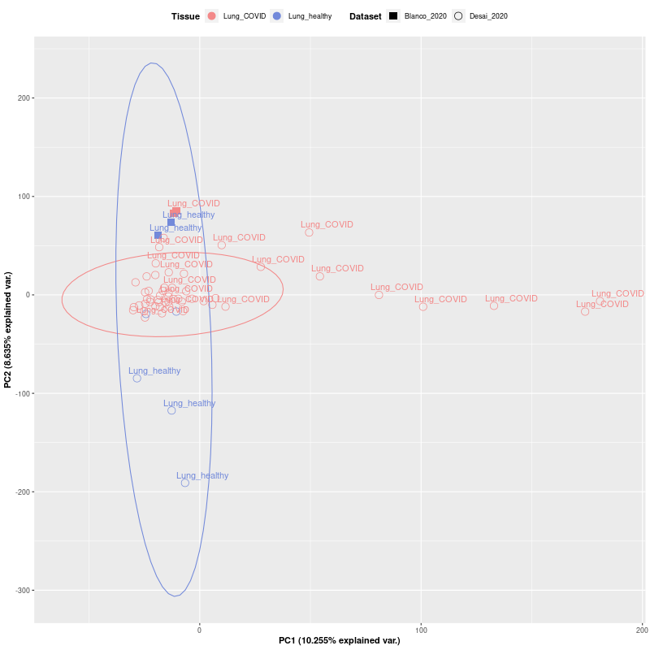

The good news is that we can see two groups: healthy samples and COVID samples. Some COVID samples merge together, whereas others drive variation in PC1. However, there is no clear separation between datasets in a condition wise manner.

- PC3&4

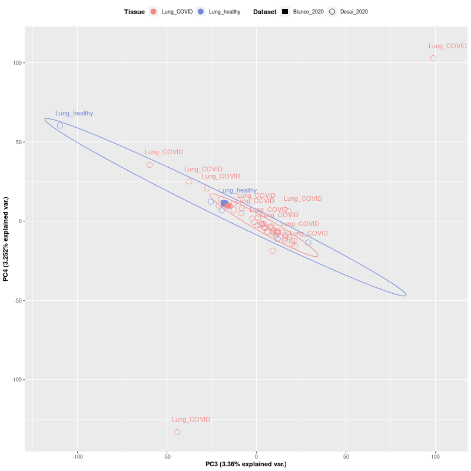

- PC5&6

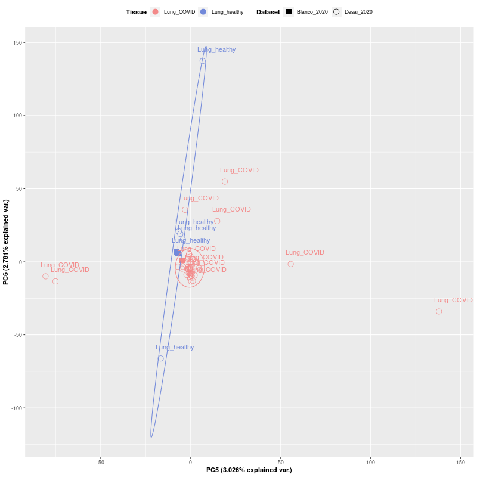

- PC7&8

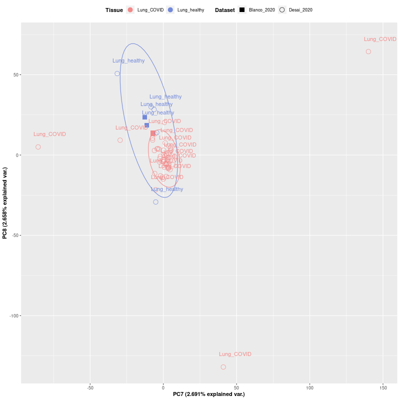

#### **Blanco + Desai + Delorey (batch correction joined)**

##### **Load, join and clean data**

```r
# counts matrix - batch corrected
lung <- as.data.frame(read.csv(file = "/mnt/Citosina/amedina/mpadilla/COVID19/Data/multi-datasets/counts/blanco2020-desai2020-delorey2021-mer-adj-counts-Lung-fltrtrxs.csv", sep = ","))
dim(lung) #   78 20299

## format delorey samples names
rownames(lung) <- str_remove(rownames(lung),"^X")
rownames(lung) <- str_replace_all(rownames(lung),"\\.","-")

## filter genes with zero counts and replace 0s for NAs
lung[is.na(lung)] <- 0
lung <- lung[,which(apply(lung, 2, var) != 0)] #    78 19919
```

##### **PCA**

Label vectors:

```r
# order meta
order <- match(rownames(lung),meta.sub.lung$sample)
meta.sub.lung <- meta.sub.lung[order,]

# Create vector of experiment labels
experiments <- meta.sub.lung$source
dataset <- as.factor(meta.sub.lung$dataset)
```

PCA computation and visualization

```r
pca <- prcomp(lung, scale = T)

## add labels to pca obj
pca$x <- add_column(as.data.frame(pca$x), experiments)
pca$x <- add_column(as.data.frame(pca$x), dataset)

## ggplot2 col-SC2inf  shape -experiments
png(file = "./plots_3analysis-bc/lung/pca_blanco2020-desai2020-delorey2021_mer-adj_Lung_PC34.png",
    width = 800, height = 800)
ggplot(pca$x, aes(x=PC3, y=PC4, group=experiments)) +
  geom_point(size=4, aes(shape=dataset, color=experiments)) +
  stat_ellipse(aes(color=experiments), show.legend = F) +
  scale_shape_manual(values=c(15,1,9), name="Dataset") +
  scale_colour_manual(values=c("#f38989","#7289da"), name="Tissue") +
  labs(x = pc.axis(3), y = pc.axis(4)) +
  theme(legend.position = "top", legend.title = element_text(face = "bold"),
        axis.title.x=element_text(face = "bold"), axis.title.y=element_text(face = "bold")) +
  geom_text(aes(label=experiments,color=experiments),
            nudge_x = 8, nudge_y = 8, show.legend = F, check_overlap = T)
dev.off()
```

- PC1&2

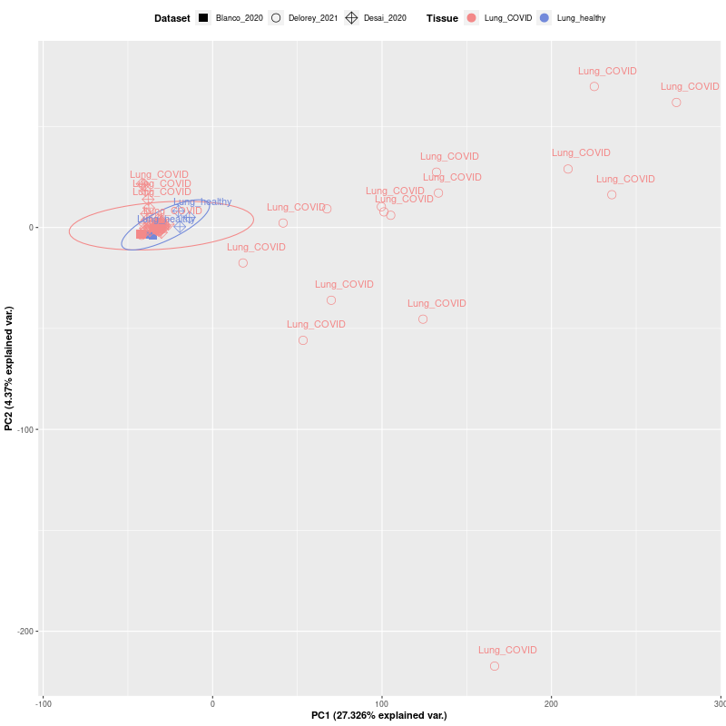

Delorey’s data is very disperse. But the definition of groups has definitely improved in comparision from when the analysis wasnt split.

- PC3&4

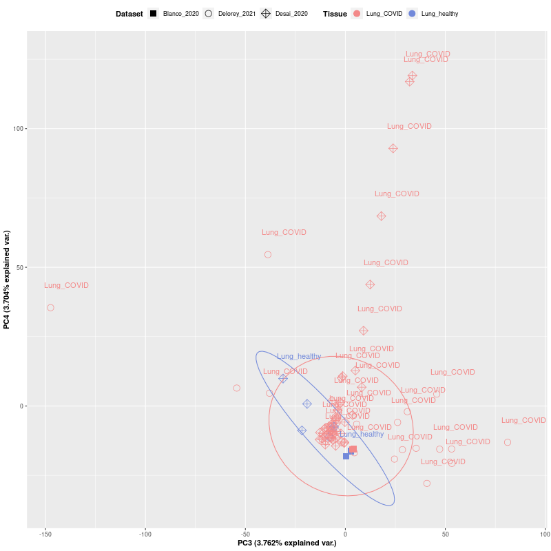

There is still the group of `Healthy Lung` samples. Also, `Lung COVID` samples from different datasets are merging together, but with still a bias.

- PC5&6

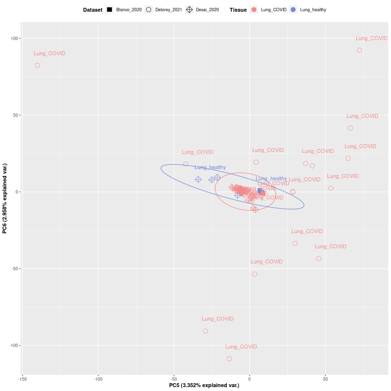